# Chapter3

Mai Vu

11/13/2019

# Chapter 3

# Q2 Read data and print out the names of the variables in the data

## describe the data set briefly

This data approach student achievement in secondary education of two Portuguese schools. The data attributes include student grades, demographic, social and school related features) and it was collected by using school reports and questionnaires.The datasets provides information regarding the performance in two distinct subjects: Mathematics (mat) and Portuguese language (por). In [Cortez and Silva, 2008], the two datasets were modeled under binary/five-level classification and regression tasks.

*Important note: the target attribute G3 has a strong correlation with attributes G2 and G1. This occurs because G3 is the final year grade (issued at the 3rd period), while G1 and G2 correspond to the 1st and 2nd period grades. It is more difficult to predict G3 without G2 and G1, but such prediction is much more useful (see paper source for more details). The data (n=382) has 35 different variables and is a joined data of the two datasets.

- The names of the variables including

+*school*: binary variables: ‘GP’ - Gabriel Pereira or ‘MS’ - Mousinho da Silveira

- Characteristics of participants: *sex* , *age*
- Demographic and family information including variables: *Address*, *famsize*, *Pstatus*, *Medu*, *Fedu*,
- Some variables about educational information: *absences* - numeric variable- number of school absences, *failures*: - number of past class failures, *nursery*: - attended nursery school (binary: yes or no), *internet*: - Internet access at home (binary: yes or no), *guardian*: - student’s guardian (nominal: ‘mother’, ‘father’ or ‘other’)

*G1*, *G2*, *G3*: express grades are related with the course subject, Math or Portuguese.

# Q3: choose 4 interesting variables in the data and predict the association between them and *high_alc*

So I want to see how age (*age*). sex (*sex*), a romantic relationship (* romantic *), and number of school absences (*absences*) variables effect to cohort consumption.

The hyopthesis is that getting older, being male, not in good relationship with partner, and more days of school absence will increase alcohol consumption.

# Q4: Numerically and graphically explore the distributions of chosen variables

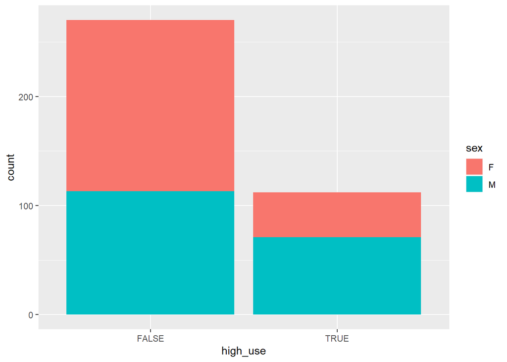

```r
g1 <- ggplot(data = dat, aes(x = high_use, fill = sex))
g1 + geom_bar()
```

From the plot 1, it can be seen that male take higher proportion than female in high_use.

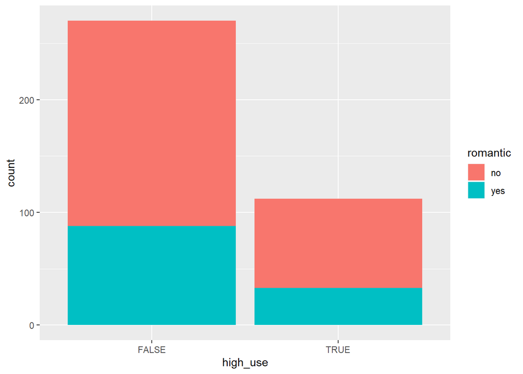

```r
g2 <- ggplot(data = dat, aes(x = high_use, fill =  romantic ))
g2 + geom_bar()
```

It can be seen here somehow not in a romantic relationship took more proportion of datohol consumption compare to in a romantic relationship

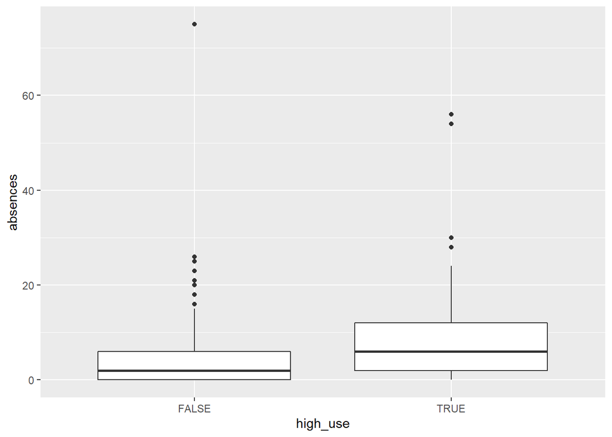

```r
g3 <- ggplot(data = dat, aes(x = high_use, y= absences))
g3 + geom_boxplot()
```

More day absences from school increased datohol consumption

#Q5: Logistic regression model

```r
m <- glm(high_use ~ age+ sex + romantic+ absences, data = dat, family = "binomial")
summary(m)
```

```
##
## Call:
## glm(formula = high_use ~ age + sex + romantic + absences, family = "binomial",
##     data = dat)
##
## Deviance Residuals:
##     Min       1Q   Median       3Q      Max
## -2.7179  -0.8456  -0.6286   1.0823   2.1893
##
## Coefficients:
##             Estimate Std. Error z value Pr(>|z|)
## (Intercept) -4.54258    1.70433  -2.665  0.00769 **
## age          0.16915    0.10226   1.654  0.09810 .
## sexM         0.99159    0.24303   4.080 4.50e-05 ***
## romanticyes -0.29584    0.26585  -1.113  0.26579
## absences     0.07283    0.01828   3.983 6.79e-05 ***
## ---
## Signif. codes:  0 '***' 0.001 '**' 0.01 '*' 0.05 '.' 0.1 ' ' 1
##
## (Dispersion parameter for binomial family taken to be 1)
##
##     Null deviance: 462.21  on 381  degrees of freedom
## Residual deviance: 422.16  on 377  degrees of freedom
## AIC: 432.16
##
## Number of Fisher Scoring iterations: 4
```

```r
OR <- coef(m) %>% exp
CI <- confint(m) %>% exp
cbind (OR, CI)
```

```
##                     OR        2.5 %   97.5 %
## (Intercept) 0.01064589 0.0003570945 0.290015
## age         1.18430022 0.9701859445 1.450229
## sexM        2.69551085 1.6842578252 4.375275
## romanticyes 0.74390627 0.4371001910 1.242806
## absences    1.07554516 1.0398995842 1.116863
```

Interpret result: + Age: getting older has associate to increase datohol usage, however, the effect of age variable is not significant (P-value = 0.10 )

- Being a male increase probability use more datohol than 2.69 being female (OR = 2.69), the result is statistical significant
- In a romantic relationship decrease alcohol consumption, however, the effect of this variable is not significant (P-value = 0.26)
- The number of day absences from school increase the probability of use more datohol 1.07 (95%CI = 1.04 - 1.11)

```r
probabilities <- predict(m, type = "response")

dat <- mutate(dat, probability = probabilities)

dat <- mutate(dat, prediction = probabilities > 0.5)

# tabulate the target variable versus the predictions

table(high_use = dat$high_use, prediction = dat$prediction)
```

```
##         prediction
## high_use FALSE TRUE
##    FALSE   261    9
##    TRUE     88   24
```

```r
loss_func <- function(class, prob) {
  n_wrong <- abs(class - prob) > 0.5
  mean(n_wrong)}

library(boot)
cv <- cv.glm(data = dat, cost = loss_func, glmfit = m, K = nrow(dat))
summary (cv)
```

```
##       Length Class  Mode
## call    5    -none- call
## K       1    -none- numeric
## delta   2    -none- numeric
## seed  626    -none- numeric
```